# Questions 1 and 2: Outlier Analysis and EDA

Navin Lo

2024-10-27

# 1. What do you imagine is the reason for log-transforming the protein levels in `biomarker-raw.csv`? (Hint: look at the distriution of raw values for a sample of proteins)

```r
# load the data
var_names <- read_csv('../../data/biomarker-raw.csv',
                     col_names = F,
                     n_max = 2,
                     col_select = -(1:2)) %>%
  t() %>%
  as_tibble() %>%
  rename(name = V1,
         abbreviation = V2) %>%
  na.omit()
biomarker_clean <- read_csv('../../data/biomarker-raw.csv',
         skip = 2,
         col_select = -2L,
         col_names = c('group',
                       'empty',
                       pull(var_names, abbreviation),
                       'ados'),
         na = c('-', ''),
         show_col_types = FALSE) %>%
  filter(!is.na(group))

head(biomarker_clean)
```

```
## # A tibble: 6 × 1,319
##   group  CHIP CEBPB   NSE PIAS4 `IL-10 Ra` STAT3  IRF1 `c-Jun` `Mcl-1`  OAS1
##   <chr> <dbl> <dbl> <dbl> <dbl>      <dbl> <dbl> <dbl>   <dbl>   <dbl> <dbl>
## 1 ASD    619. 1489.  733. 1230.      1647   467  1041    3114.   1248.  490.
## 2 ASD    512. 1698. 2628. 1484.      1712.  548. 1214.   3188     868.  649.
## 3 ASD    438. 1122.  857. 1419.      1926.  413. 1222.   2373.   1203   496.
## 4 ASD    505  1210. 1394  1036.      1552.  523. 1982.   2652.    764.  523
## 5 ASD    441. 1120.  885   926.      1518.  524. 1422.   2374.    648.  693.
## 6 ASD    499. 1822.  658. 1087.      1651.  459  1203.   3050.   2717.  545.
## # ℹ 1,308 more variables: `c-Myc` <dbl>, SMAD3 <dbl>, SMAD2 <dbl>,
## #   `IL-23` <dbl>, PDGFRA <dbl>, `IL-12` <dbl>, STAT1 <dbl>, STAT6 <dbl>,
## #   LRRK2 <dbl>, Osteocalcin <dbl>, `IL-5` <dbl>, GPDA <dbl>, IgA <dbl>,
## #   LPPL <dbl>, HEMK2 <dbl>, PDXK <dbl>, TLR4 <dbl>, REG4 <dbl>,
## #   `HSP 27` <dbl>, `YKL-40` <dbl>, `Alpha enolase` <dbl>, `Apo L1` <dbl>,
## #   CD38 <dbl>, CD59 <dbl>, FABPL <dbl>, `GDF-11` <dbl>, BTC <dbl>,
## #   `HIF-1a` <dbl>, S100A6 <dbl>, SECTM1 <dbl>, RSPO3 <dbl>, PSP <dbl>, …
```

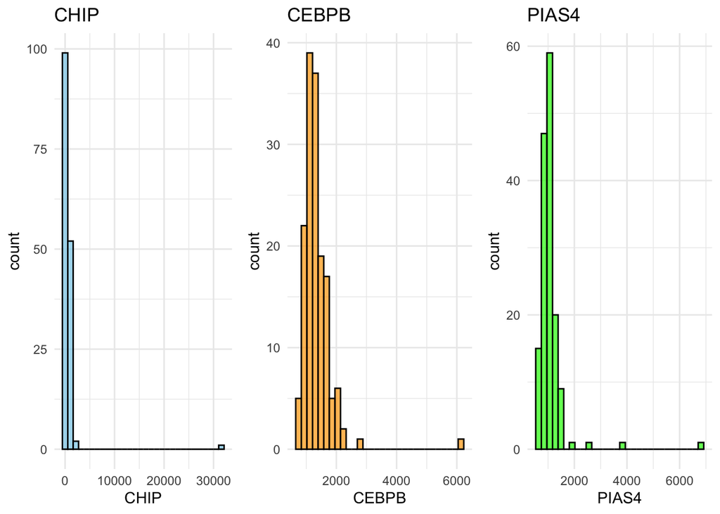

```r
# plot individual proteins
p1 <- ggplot(biomarker_clean, aes(x = CHIP)) +
  geom_histogram(bins = 30, fill = "skyblue", color = "black", alpha = 0.7) +
  labs(title = "CHIP") +
  theme_minimal()

p2 <- ggplot(biomarker_clean, aes(x = CEBPB)) +
  geom_histogram(bins = 30, fill = "orange", color = "black", alpha = 0.7) +
  labs(title = "CEBPB") +
  theme_minimal()

p3 <- ggplot(biomarker_clean, aes(x = PIAS4)) +
  geom_histogram(bins = 30, fill = "green", color = "black", alpha = 0.7) +
  labs(title = "PIAS4") +
  theme_minimal()

# make it a grid
grid.arrange(p1, p2, p3, ncol = 3)
```

After investigating some of the protein levels in `biomarker-raw.csv`, the reason for log-transforming the data is to reduce the significant skew that each of these proteins comes with. As a result, it would be very difficult to perform any analysis on data this skewed.

```r
# take the log, then look at the same proteins
log_biomarker_clean = biomarker_clean %>%
  mutate(across(.cols=-c(group, ados), ~ log10(.x)))
```

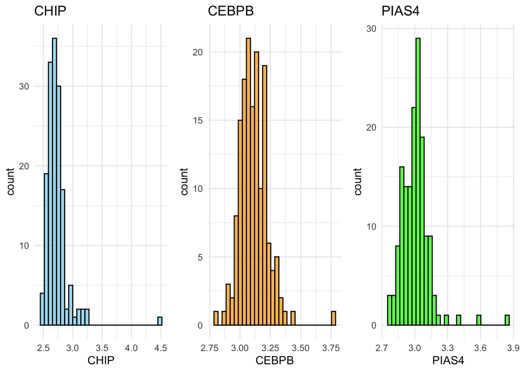

```r
# plot individual proteins
p1 <- ggplot(log_biomarker_clean, aes(x = CHIP)) +
  geom_histogram(bins = 30, fill = "skyblue", color = "black", alpha = 0.7) +
  labs(title = "CHIP") +
  theme_minimal()

p2 <- ggplot(log_biomarker_clean, aes(x = CEBPB)) +
  geom_histogram(bins = 30, fill = "orange", color = "black", alpha = 0.7) +
  labs(title = "CEBPB") +
  theme_minimal()

p3 <- ggplot(log_biomarker_clean, aes(x = PIAS4)) +
  geom_histogram(bins = 30, fill = "green", color = "black", alpha = 0.7) +
  labs(title = "PIAS4") +
  theme_minimal()

# make it a grid
grid.arrange(p1, p2, p3, ncol = 3)
```

After log transforming the data, it becomes much less skewed, which helps stabilize variance data and makes extreme values less influential. This transformation often “normalizes” the data, allowing for better model accuracy and interpretability.

# 2. Temporarily remove the outlier trimming from preprocessing and do some exploratory analysis of outlying values. Are there specific *subjects* (not values) that seem to be outliers? If so, are outliers more frequent in one group or the other? (Hint: consider tabulating the number of outlying values per subject.)

```r
# reload the data, but do not trim outliers
clean_data_with_outliers <- read_csv('../../data/biomarker-raw.csv',
         skip = 2,
         col_select = -2L,
         col_names = c('group',
                       'empty',
                       pull(var_names, abbreviation),
                       'ados'),
         na = c('-', ''),
         show_col_types=FALSE) %>%
  filter(!is.na(group)) %>%
  # log transform, center, and scale without trimming
  mutate(across(.cols = -c(group, ados),
                ~ scale(log10(.x))[, 1])) %>%
  # reorder columns
  select(group, ados, everything())
```

Defining an outlier as being outside of 3 standard deviations from the mean of a given protein. Take the sum of each protein for a given subject.

```r
is_outlier <- function(x) {
  abs(scale(x)) > 3
}

# Apply the outlier detection process and count outliers for each subject
outlier_counts <- clean_data_with_outliers %>%
  # Flag outliers across all protein columns, excluding 'group' and 'ados'
  mutate(across(.cols = -c(group, ados), ~ is_outlier(.x))) %>%
  # Count the number of outliers per subject
  rowwise() %>%
  mutate(outlier_count = sum(c_across(-c(group, ados)))) %>%
  ungroup() %>%
  # Select relevant columns for viewing
  select(group, outlier_count, ados)
```

“Outlier subject” is someone who is in the 75th percentile or greater in terms of number of outlying proteins.

```r
percentile_75 = quantile(outlier_counts$outlier_count, 0.75)
percentile_90 = quantile(outlier_counts$outlier_count, 0.9)
percentile_95 = quantile(outlier_counts$outlier_count, 0.95)

outlying_subjects_75 = outlier_counts %>%
  filter(outlier_count > percentile_75)

outlying_subjects_90 = outlier_counts %>%
  filter(outlier_count > percentile_90)

outlying_subjects_95 = outlier_counts %>%
  filter(outlier_count > percentile_95)
```

```r
outlying_subjects_75 %>%
  group_by(group) %>%
  summarize(count=n())
```

```
## # A tibble: 2 × 2
##   group count
##   <chr> <int>
## 1 ASD      17
## 2 TD       22
```

```r
outlying_subjects_90 %>%
  group_by(group) %>%
  summarize(count=n())
```

```
## # A tibble: 2 × 2
##   group count
##   <chr> <int>
## 1 ASD       5
## 2 TD       11
```

```r
outlying_subjects_95 %>%
  group_by(group) %>%
  summarize(count=n())
```

```
## # A tibble: 2 × 2
##   group count
##   <chr> <int>
## 1 ASD       3
## 2 TD        5
```

By analyzing the outlying subjects in the study, it is clear that there are more “outlier subjects” in the typical development group.